# Part II - A Comprehensive Analysis Into the Exploration of Loan Default Rates

## by Nasser Kaze

## Investigation Overview

I sought to observe the factors that have a strong influence on loan default rate which could proof very helpful to determine the credit scores and mitigating risks of loan default.

## Dataset Overview

The data consists of 113,937 loans with 81 variables on each loan including loan amount, borrower(interest) rate, current loan status, borrower income, and many others. Some variables had to be simplified or summarized into smaller categories to make the analysis clearer and understandable. There are also so many variables, it would be too cumbersome to investigate them all. So the study focused on a few variables.

## Percentage Of Loans by Status

The loan status shows the default rate of the loans with defaulted loans making up 30 percent of the dataset and Completed or Fully paid loans making up the remaining 70 percent which can be observed on the pie chart below.

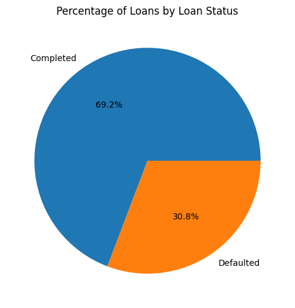

## Percentage Of Loans By Home Ownership Status

Home Ownership have a more balanced distribution with `47%` being home owners and the remaining `53%` non-home owners. This is can be seen in the Pie Chart below.

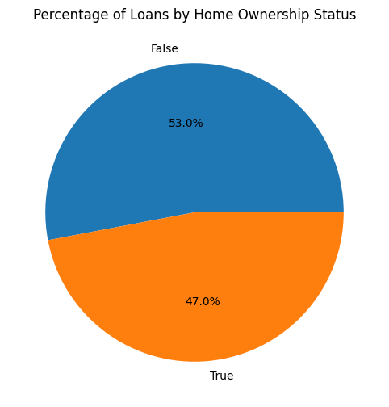

## Distribution of Income Ranges

Income Ranges between `$25,000` and `$50,000` have the largest range of values. Follows is a step wise drop with increase in Income Range. The dataset also features very small `$0` income earners and also small low income earners in the range `$1` to `$25,000`.

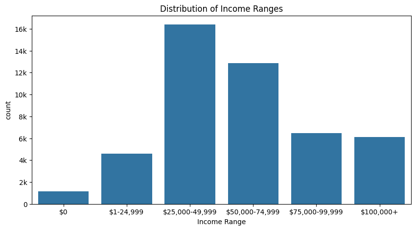

## Distribution of Loan Grades

A bar plot of the distribution of Loan Grades shows that Loans with grade `D` and `C` are more popular among borrowers. The other loan grades where almost equally requested.

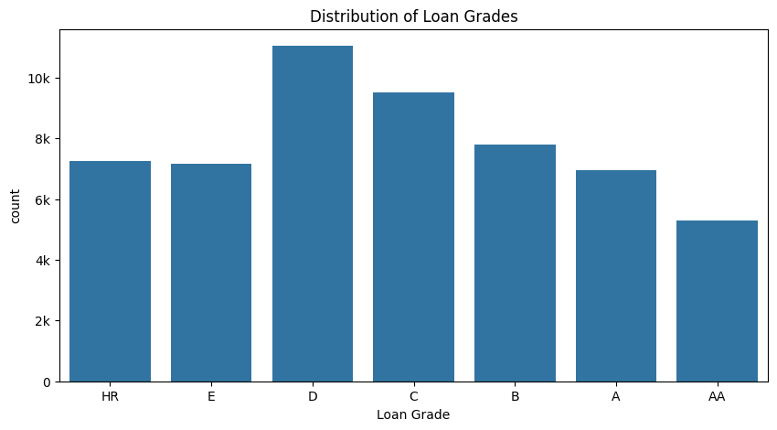

## Distribution of Loan Amount

The distribution of the loan amount is skewed to the right. When observed on a log scale, we notice a concentration of loans below `$5,000`. The frequency steadily drops as the amount increases with a few show outbursts at `$10,000`, `$15,000` and `$25,000`.

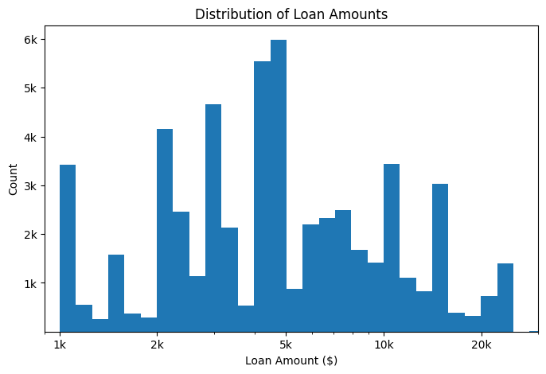

## Loan Amount vs. Income Range

Grouping and plotting the Loan Amount by Income Range, We can see that borrowers with higher incomes tend to have larger loans as depicted with the steady increment step in loan amounts with increase in the income range. We can also observe large loans among `$0` income earners which suggests a need for financial support given the income as expected.

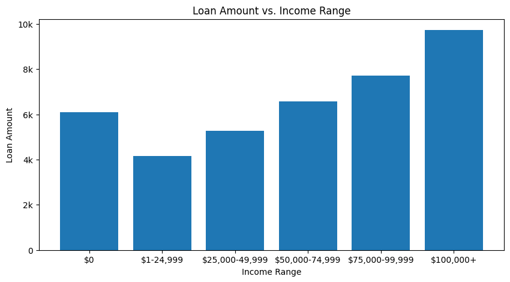

## Loan Amount and Loan Grade by Loan Status

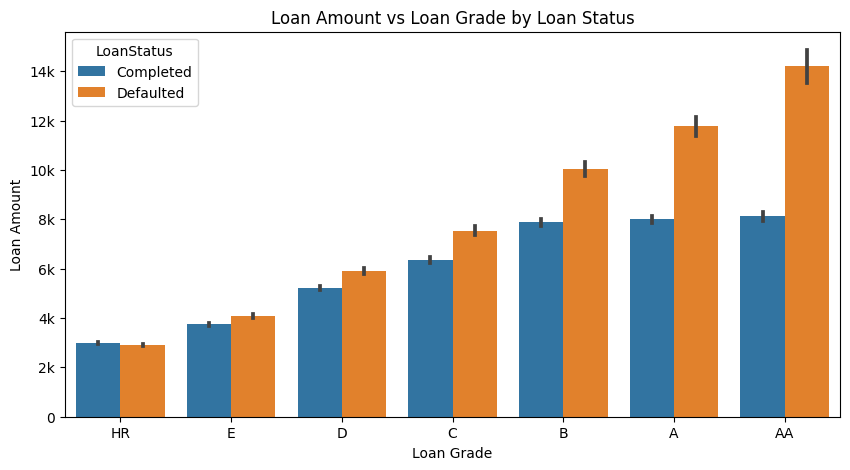

## Loan Amount and Loan Purpose by Loan Status

Investigating the impact of the loan amount with respect to the loan purpose with the Loan Status also show that the loan purpose is a significant factor in determining loan amounts as well as default rates. We can see for the case of loans taken for boats, we observe that loans taken below the median value of `$8,000` had lower default and the default is higher above the median. We can also observe a the case of loans taken for cosmetic procedures. Smaller amounts at `$3,000` had lower default rates and default rate increased as the amount borrowed increased.

Overall, we can see that depending on the purpose of the loan, the amount borrowed could have a strong impact on the default rate.

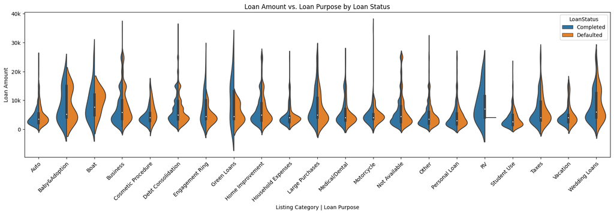